# Clustering

Rajesh Majumder

2023-11-27

## 0.1 Data Preparation

- Data should be in a tabular format where rows are observations and columns are variables.
- No missing observations.
- Data must be standardized $\{\frac{x_i-\bar{x}}{s}\}$

## 0.2 Required Packages

Here we’ll use mainly the following R packages:

- `cluster` for computing clustering algorithms, and
- `factoextra` for ggplot2-based elegant visualization of clustering results.

`factoextra` contains many functions for cluster analysis and visualization, including:

| Functions | Descriptions |
| --- | --- |
| `dist(fviz_dist, get_dist)` | Distance Matrix Computation and Visualization |
| `get_clust_tendency` | Assessing Clustering Tendency |
| `fviz_nbclust(fviz_gap_stat)` | Determining the Optimal Number of Clusters |
| `fviz_dend` | Enhanced Visualization of Dendrogram |
| `fviz_cluster` | Visualize Clustering Results |
| `fviz_mclust` | Visualize Model-based Clustering Results |
| `fviz_silhouette` | Visualize Silhouette Information from Clustering |
| `hcut` | Computes Hierarchical Clustering and Cut the Tree |
| `hkmeans` | Hierarchical k-means clustering |
| `eclust` | Visual enhancement of clustering analysis |

```r
install.packages(c("cluster", "factoextra"))
```

## 0.3 Clustering Distance Measures

The classification of observations into groups requires some methods for computing the distance or the (dis)similarity between each pair of observations. The result of this computation is known as a dissimilarity or distance matrix.The choice of distance measures is a critical step in clustering. It defines how the similarity of two elements (x, y) is calculated and it will influence the shape of the clusters.

There are many methods to calculate this distance information.Here are the common distance measures:

Let $x^{n\times 1} \text{ and } y^{n\times 1}$ are two vectors.

### 0.3.1 The classical methods:

### 0.3.2 (1) Euclidean distance:

$$d_{euc}(x,y)=\sqrt{{\sum}_{i=1}^n
(x_i-y_i)^2}$$

### 0.3.3 (2) Manhattan distance:

$$d_{man}(x,y)=\sqrt{{\sum}_{i=1}^n
\mid(x_i-y_i)\mid}$$

### 0.3.4 Correlation-based distances:

This are widely used for gene expression data analyses. Correlation-based distance is defined by subtracting the correlation coefficient from 1. Different types of correlation methods can be used such as:

### 0.3.5 (1) Pearson correlation distance:

$$d_{cor}(x,y)=1-r_{xy} \:\:
\text{where}\: r_{xy}\; \text{is the Pearson correlation b/w x and
y}$$

Pearson correlation measures the degree of a linear relationship between two profiles.

### 0.3.6 (2) Eisen cosine correlation distance:

It’s a special case of Pearson’s correlation with $\bar{x}$ and $\bar{y}$ both replaced by zero:

$$d_{eisen}(x,y)=1-\frac{\mid{\sum}_{i=1}^n x_i y_i
\mid}{\sqrt{{\sum}_{i=1}^n x_i^2 {\sum}_{i=1}^n y_i^2}}$$

### 0.3.7 (3) Spearman correlation distance:

The spearman correlation method computes the correlation between the rank of x and the rank of y variables.

$$d_{spear}(x,y)=1-r_{spear}(xy) \:\:
\text{where}\: r_{spear}(xy)\; \text{is the Spearman correlation b/w x
and y}$$

### 0.3.8 (4) Kendall correlation distance:

Kendall correlation method computes the correlation between the rank of x and the rank of y variables.

$$d_{kend}(x,y)=1-r_{kend}(xy) \:\:
\text{where}\: r_{spear}(xy)\; \text{is the Kendall correlation b/w x
and y}$$

**NOTE**

- Pearson, used for two quantitative continuous variables which have a linear relationship
- Spearman, used for two quantitative variables if the link is partially linear, or for one qualitative ordinal variable and one quantitative variable
- Kendall, often used for two qualitative ordinal variables

### 0.3.9 What type of distance measures should we choose?

- The choice of distance measures is very important. For most common clustering software, the default distance measure is the Euclidean distance but depending on the type of the data other dissimilarity measures might be preferred. For example, correlation-based distance is often used in gene expression data analysis.
- Correlation-based distance considers two objects to be similar if their features are highly correlated, even though the observed values may be far apart in terms of Euclidean distance.
- The distance between two objects is 0 when they are perfectly correlated.
- Pearson’s correlation is quite sensitive to outliers. This does not matter when clustering samples, because the correlation is over thousands of genes.
- When clustering genes, it is important to be aware of the possible impact of outliers. This can be mitigated by using Spearman’s correlation instead of Pearson’s correlation.
- If we want to identify clusters of observations with the same overall profiles regardless of their magnitudes, then we should go with correlation-based distance as a dissimilarity measure. This is particularly the case in gene expression data analysis, where we might want to consider genes similar when they are “up” and “down” together. It is also the case, in marketing if we want to identify group of shoppers with the same preference in term of items, regardless of the volume of items they bought.
- If Euclidean distance is chosen, then observations with high values of features will be clustered together. The same holds true for observations with low values of features.

## 0.4 Distance matrix computation

#### 0.4.0.1 Data preparation

Here we are using a subset of 15 random samples of USArrests dataset. Next, we standardize the data using the function `scale()`.

```r
set.seed(123)
id= sample(1:dim(USArrests)[1],15,replace = FALSE)
data= USArrests[id,]
data=scale(data)
head(data)
```

```
##                Murder     Assault   UrbanPop        Rape
## New Mexico  0.5850809  1.02300309  0.2250557  0.61101857
## Iowa       -1.7022042 -1.54760088 -0.6892332 -1.43885018
## Indiana    -0.4591145 -0.90775622 -0.1265939 -0.48290177
## Arizona    -0.2353583  1.12403120  0.9283549  0.50261205
## Tennessee   1.0325932 -0.06585536 -0.5485734  0.09855138
## Texas       0.9082842  0.08007413  0.9283549 -0.03942055
```

#### 0.4.0.2 R functions and packages

There are many R functions for computing distances between pairs of observations:

- 1. `dist()` R base function [`stats` package]: Accepts only numeric data as an input.
- 2. `get_dist()` function [`factoextra` package]: Accepts only numeric data as an input. Compared to the standard dist() function, it supports correlation-based distance measures including “pearson”, “kendall” and “spearman” methods.
- 3. `daisy()` function [cluster package]: Able to handle other variable types (e.g. nominal, ordinal, (a)symmetric binary). In that case, the Gower’s coefficient will be automatically used as the metric. It’s one of the most popular measures of proximity for mixed data types.

#### 0.4.0.3 Computing euclidean distance

```r
dist.eucl= dist(data, method = "euclidean")

## Other methods are “euclidean”, “maximum”, “manhattan”, “canberra”, “binary”, “minkowski”.

round(as.matrix(dist.eucl)[1:3,1:3],1)
```

```
##            New Mexico Iowa Indiana
## New Mexico        0.0  4.1     2.5
## Iowa              4.1  0.0     1.8
## Indiana           2.5  1.8     0.0
```

In this matrix, the value represent the distance between objects. The values on the diagonal of the matrix represent the distance between objects and themselves (which are zero).

Note that, if we want to compute pairwise distances between variables, we must start by transposing the data before using the dist() function. The function t() is used for transposing the data.

#### 0.4.0.4 Computing correlation based distances

```r
library(factoextra)
dist.cor= get_dist(data, method = "pearson")
round(as.matrix(dist.cor)[1:3,1:3],1)
```

```
##            New Mexico Iowa Indiana
## New Mexico        0.0  1.7     2.0
## Iowa              1.7  0.0     0.3
## Indiana           2.0  0.3     0.0
```

#### 0.4.0.5 Computing distances for mixed data

The function `daisy()` [cluster package] provides a solution (Gower’s metric) for computing the distance matrix, in the situation where the data contain no-numeric columns. flower dataset is a such kind of data:

```r
library(cluster)

# Load data

data(flower)
head(flower, 3)
```

```
##   V1 V2 V3 V4 V5 V6  V7 V8
## 1  0  1  1  4  3 15  25 15
## 2  1  0  0  2  1  3 150 50
## 3  0  1  0  3  3  1 150 50
```

```r
# Data structure
str(flower)
```

```
## 'data.frame':    18 obs. of  8 variables:
##  $ V1: Factor w/ 2 levels "0","1": 1 2 1 1 1 1 1 1 2 2 ...
##  $ V2: Factor w/ 2 levels "0","1": 2 1 2 1 2 2 1 1 2 2 ...
##  $ V3: Factor w/ 2 levels "0","1": 2 1 1 2 1 1 1 2 1 1 ...
##  $ V4: Factor w/ 5 levels "1","2","3","4",..: 4 2 3 4 5 4 4 2 3 5 ...
##  $ V5: Ord.factor w/ 3 levels "1"<"2"<"3": 3 1 3 2 2 3 3 2 1 2 ...
##  $ V6: Ord.factor w/ 18 levels "1"<"2"<"3"<"4"<..: 15 3 1 16 2 12 13 7 4 14 ...
##  $ V7: num  25 150 150 125 20 50 40 100 25 100 ...
##  $ V8: num  15 50 50 50 15 40 20 15 15 60 ...
```

```r
# Distance matrix
dist.mixed= daisy(flower)
round(as.matrix(dist.mixed)[1:3, 1:3], 2)
```

```
##      1    2    3
## 1 0.00 0.89 0.53
## 2 0.89 0.00 0.51
## 3 0.53 0.51 0.00
```

#### 0.4.0.6 Visualizing distance matrices

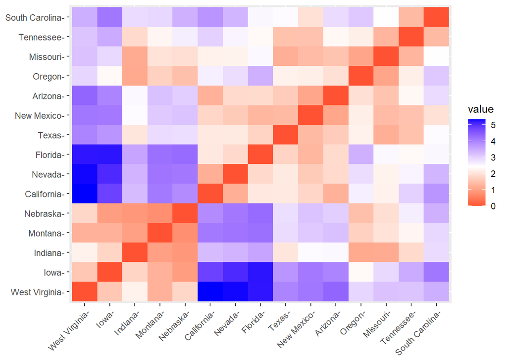

```r
library(factoextra)
fviz_dist(dist.eucl)
```

- **Red: high similarity (ie: low dissimilarity) | Blue: low similarity**

## 0.5 K-Means Clustering

K-means clustering (MacQueen 1967) is one of the most commonly used unsupervised machine learning algorithm for partitioning a given data set into a set of k groups (i.e. k clusters), where k represents the number of groups pre-specified by the analyst. It classifies objects in multiple groups (i.e., clusters), such that objects within the same cluster are as similar as possible (i.e., high intra-class similarity), whereas objects from different clusters are as dissimilar as possible (i.e., low inter-class similarity). In k-means clustering, each cluster is represented by its center (i.e, centroid) which corresponds to the mean of points assigned to the cluster.

### 0.5.1 K-means basic ideas

Let $\mathbf{x}^{d\times 1}_1,\mathbf{x}^{d\times 1}_2,...,\mathbf{x}^{d\times 1}_n$ samples, k-means clustering aims to partition the $n$ observations into $k\:\:(\leq n)$ sets $\mathbf{S}=\{S_1,S_2,...,S_k\}$ so as to minimize the within-cluster sum of squares (WCSS) (i.e. variance). Formally, the objective is to find:

$$argmin_s={\sum}_{i=1}^k{\sum}_{x\in S_i}
\left\| \mathbf{x}- \mathbf{\mu}_i\right\|^2 = argmin_s{\sum}_{i=1}^k
\mid S_i \mid \text{Var}(S_i)$$
where $\mathbf{\mu}_i$ is the mean (also called centroid) of points in $S_i$,i.e.,
$$\mathbf{\mu}_i=\frac{1}{\mid S_i \mid}
{\sum}_{\mathbf{x} \in S_i }^k \mathbf{x},$$
$\mid S_i \mid$ is the size of $S_i$, and $\left\|.\right\|$ is the usual $L^2 \text{norm}$. This is equivalent to minimizing the pairwise squared deviations of points in the same cluster:
$$argmin_s {\sum}_{i=1}^k
\frac{1}{\mid S_i \mid} {\sum}_{x, y \in S_i} \left\| \mathbf{x}-
\mathbf{y}_i\right\|^2$$
.

The equivalence can be deduced from identity $\mid S_i \mid {\sum}_{x \in S_i} \left\| \mathbf{x}- \mathbf{\mu}_i\right\|^2= \frac{1}{2} {\sum}_{x, y \in S_i} \left\| \mathbf{x}- \mathbf{y}_i\right\|^2$. Since the total variance is constant, this is equivalent to maximizing the sum of squared deviations between points in different clusters (between-cluster sum of squares, BCSS). This deterministic relationship is also related to the law of total variance in probability theory.

There are several k-means algorithms available. The standard algorithm is the Hartigan-Wong algorithm (Hartigan and Wong 1979), which defines the total within-cluster variation as the sum of squared distances Euclidean distances between items and the corresponding centroid:
$$argmin_s={\sum}_{i=1}^k{\sum}_{x\in S_i}
(\mathbf{x}- \mathbf{\mu}_i)^2$$
.

### 0.5.2 Computing k-means clustering

#### 0.5.2.1 Data

`USArrests` Dataset

#### 0.5.2.2 Estimating the optimal number of clusters

The R function `fviz_nbclust()` [in `factoextra` package] provides a convenient solution to estimate the optimal number of clusters.

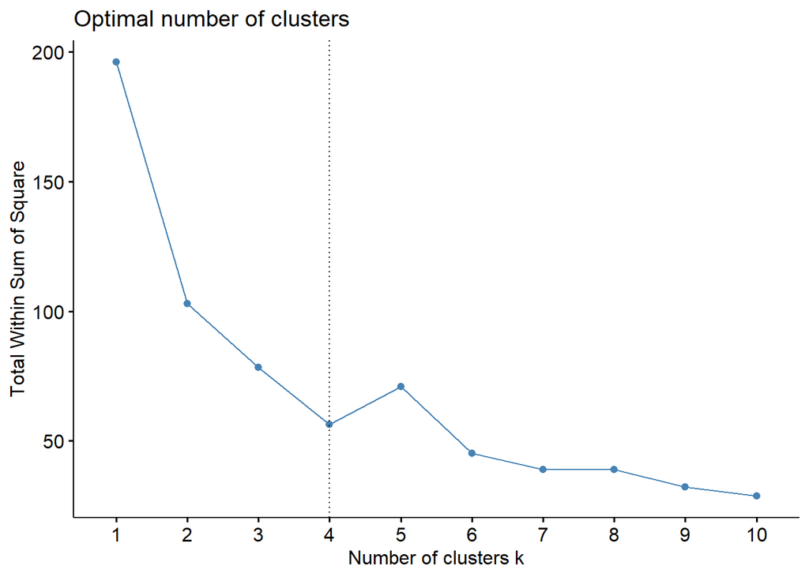

```r
data= scale(USArrests)

library(factoextra)
fviz_nbclust(data,kmeans ,method = "wss")+geom_vline(xintercept = 4,linetype="dotted")
```

#### 0.5.2.3 k-means clustering

```r
set.seed(123)
km= kmeans(data,4,nstart = 25)
km
```

```
## K-means clustering with 4 clusters of sizes 8, 13, 16, 13
##
## Cluster means:
##       Murder    Assault   UrbanPop        Rape
## 1  1.4118898  0.8743346 -0.8145211  0.01927104
## 2 -0.9615407 -1.1066010 -0.9301069 -0.96676331
## 3 -0.4894375 -0.3826001  0.5758298 -0.26165379
## 4  0.6950701  1.0394414  0.7226370  1.27693964
##
## Clustering vector:
##        Alabama         Alaska        Arizona       Arkansas     California
##              1              4              4              1              4
##       Colorado    Connecticut       Delaware        Florida        Georgia
##              4              3              3              4              1
##         Hawaii          Idaho       Illinois        Indiana           Iowa
##              3              2              4              3              2
##         Kansas       Kentucky      Louisiana          Maine       Maryland
##              3              2              1              2              4
##  Massachusetts       Michigan      Minnesota    Mississippi       Missouri
##              3              4              2              1              4
##        Montana       Nebraska         Nevada  New Hampshire     New Jersey
##              2              2              4              2              3
##     New Mexico       New York North Carolina   North Dakota           Ohio
##              4              4              1              2              3
##       Oklahoma         Oregon   Pennsylvania   Rhode Island South Carolina
##              3              3              3              3              1
##   South Dakota      Tennessee          Texas           Utah        Vermont
##              2              1              4              3              2
##       Virginia     Washington  West Virginia      Wisconsin        Wyoming
##              3              3              2              2              3
##
## Within cluster sum of squares by cluster:
## [1]  8.316061 11.952463 16.212213 19.922437
##  (between_SS / total_SS =  71.2 %)
##
## Available components:
##
## [1] "cluster"      "centers"      "totss"        "withinss"     "tot.withinss"
## [6] "betweenss"    "size"         "iter"         "ifault"
```

It’s possible to compute the mean of each variables by clusters using the original data:

```r
aggregate(USArrests, by=list(cluster=km$cluster), mean)
```

```
##   cluster   Murder   Assault UrbanPop     Rape
## 1       1 13.93750 243.62500 53.75000 21.41250
## 2       2  3.60000  78.53846 52.07692 12.17692
## 3       3  5.65625 138.87500 73.87500 18.78125
## 4       4 10.81538 257.38462 76.00000 33.19231
```

If we want to add the point classifications to the original data:

```r
dd= cbind(USArrests, cluster = km$cluster)
head(dd)
```

```
##            Murder Assault UrbanPop Rape cluster
## Alabama      13.2     236       58 21.2       1
## Alaska       10.0     263       48 44.5       4
## Arizona       8.1     294       80 31.0       4
## Arkansas      8.8     190       50 19.5       1
## California    9.0     276       91 40.6       4
## Colorado      7.9     204       78 38.7       4
```

#### 0.5.2.4 Visualizing k-means clusters

Now, we want to visualize the data in a scatter plot with coloring each data point according to its cluster assignment.

The problem is that the data contains more than 2 variables and the question is what variables to choose for the xy scatter plot.

A solution is to reduce the number of dimensions by applying a dimensionality reduction algorithm, such as Principal Component Analysis (PCA), that operates on the four variables and outputs two new variables (that represent the original variables) that you can use to do the plot. In other words, if we have a multi-dimensional data set, a solution is to perform Principal Component Analysis (PCA) and to plot data points according to the first two principal components coordinates.

The function `fviz_cluster()` [`factoextra` package] can be used to easily visualize k-means clusters. It takes k-means results and the original data as arguments. In the resulting plot, observations are represented by points, using principal components if the number of variables is greater than 2. It’s also possible to draw concentration ellipse around each cluster.

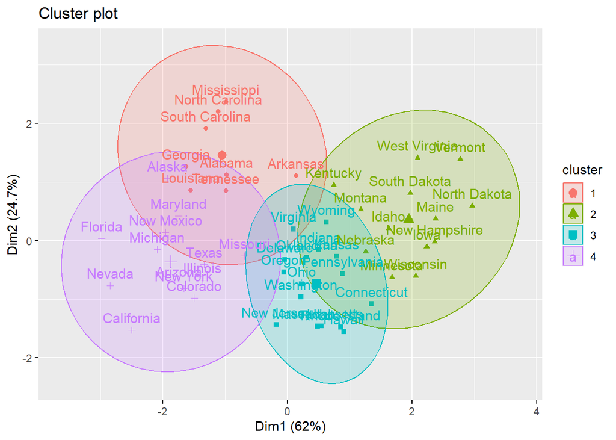

```r
library(factoextra)
fviz_cluster(km,data,ellipse.type = "norm")
```

#### 0.5.2.5 Alternative to k-means clustering

A robust alternative to k-means is PAM, which is based on medoids. PAM clustering can be computed using the function `pam()` [`cluster` package]. The function `pamk( )` [`fpc` package] is a wrapper for PAM that also prints the suggested number of clusters based on optimum average silhouette width.